# Stats 521 Final Project Jonathan Dale

Report components:  
(A) Introduction.  
(B) Descriptive Analysis.  
(C) Inference for One Parameter.  
(D) Optional: Comparison Between Two Groups Using Bootstrap  
- If your question involves comparing two groups then you should analyze the difference between groups using a bootstrap method such as: - Bootstrap CI for the difference in means  
- Bootstrap CI for the difference in proportions  
You can discuss how confidence intervals can be used for hypothesis testing as well.

## (A) Introduction.

This report is an independent data analysis which focuses on a curated sample from the National Health and Nutrition Examination Survey (NHANES). This particular data set includes health information collected on adults in the United States over the ages of 20. The survey actively collected information between the years 1999-2018 and contains 31,265 observations and 21 variables.

## (B) Descriptive Analysis.

```r
# install.packages('HDSinRdata')
library(HDSinRdata)

# Uncomment the next line to see helpful information about the data NHANESsample
# help(NHANESsample)

# View the first few rows of the NHANES Sample data, then print a summary (this will help identify any missing values).
dim(NHANESsample) # Check the dimensions
## [1] 31265    21
str(NHANESsample) # Check the structure
## 'data.frame':    31265 obs. of  21 variables:
##  $ ID           : num  2 5 12 13 14 15 20 24 25 29 ...
##  $ AGE          : num  77 49 37 70 81 38 23 53 42 62 ...
##  $ SEX          : Factor w/ 2 levels "Male","Female": 1 1 1 1 1 2 2 2 2 1 ...
##  $ RACE         : Factor w/ 5 levels "Mexican American",..: 3 3 3 1 3 3 1 3 3 3 ...
##  $ EDUCATION    : Factor w/ 3 levels "LessThanHS","HS",..: 3 3 3 1 1 3 1 2 3 2 ...
##  $ INCOME       : num  5 5 4.93 1.07 2.67 4.52 3.03 2.67 1.77 1.07 ...
##  $ SMOKE        : Factor w/ 3 levels "NeverSmoke","QuitSmoke",..: 1 2 1 2 3 3 2 3 2 2 ...
##  $ YEAR         : num  1999 1999 1999 1999 1999 ...
##  $ LEAD         : num  5 1.6 2.4 1.6 5.5 1.5 1 3.8 0.9 1.9 ...
##  $ BMI_CAT      : Factor w/ 3 levels "BMI<=25","25<BMI<30",..: 1 2 3 2 2 2 1 2 3 3 ...
##  $ LEAD_QUANTILE: Factor w/ 4 levels "Q1","Q2","Q3",..: 4 3 4 3 4 3 2 4 2 3 ...
##  $ HYP          : num  0 1 1 1 1 0 0 0 1 1 ...
##  $ ALC          : chr  "Yes" "Yes" "Yes" "Yes" ...
##  $ DBP1         : num  58 82 108 78 56 68 56 78 NA 70 ...
##  $ DBP2         : num  56 84 98 62 NA 68 58 70 86 76 ...
##  $ DBP3         : num  56 82 100 70 58 70 62 72 86 66 ...
##  $ DBP4         : num  NA NA NA NA 64 NA NA NA 84 NA ...
##  $ SBP1         : num  106 122 182 140 142 106 102 110 NA 124 ...
##  $ SBP2         : num  98 122 172 130 NA 112 102 116 120 122 ...
##  $ SBP3         : num  98 122 176 130 134 106 104 112 118 126 ...
##  $ SBP4         : num  NA NA NA NA 138 NA NA NA 120 NA ...
head(NHANESsample) # View the first few rows
```

|  | ID | AGE | SEX | RACE | EDUCATION | INCOME | SMOKE | YEAR | LEAD | BMI_CAT | LEAD_QUANTILE | HYP | ALC | DBP1 | DBP2 | DBP3 | DBP4 | SBP1 | SBP2 | SBP3 | SBP4 |
| --- | --- | --- | --- | --- | --- | --- | --- | --- | --- | --- | --- | --- | --- | --- | --- | --- | --- | --- | --- | --- | --- |
| 1 | 2 | 77 | Male | Non-Hispanic White | MoreThanHS | 5.00 | NeverSmoke | 1999 | 5.0 | BMI<=25 | Q4 | 0 | Yes | 58 | 56 | 56 | NA | 106 | 98 | 98 | NA |
| 2 | 5 | 49 | Male | Non-Hispanic White | MoreThanHS | 5.00 | QuitSmoke | 1999 | 1.6 | 25<BMI<30 | Q3 | 1 | Yes | 82 | 84 | 82 | NA | 122 | 122 | 122 | NA |
| 3 | 12 | 37 | Male | Non-Hispanic White | MoreThanHS | 4.93 | NeverSmoke | 1999 | 2.4 | BMI>=30 | Q4 | 1 | Yes | 108 | 98 | 100 | NA | 182 | 172 | 176 | NA |
| 4 | 13 | 70 | Male | Mexican American | LessThanHS | 1.07 | QuitSmoke | 1999 | 1.6 | 25<BMI<30 | Q3 | 1 | Yes | 78 | 62 | 70 | NA | 140 | 130 | 130 | NA |
| 5 | 14 | 81 | Male | Non-Hispanic White | LessThanHS | 2.67 | StillSmoke | 1999 | 5.5 | 25<BMI<30 | Q4 | 1 | Yes | 56 | NA | 58 | 64 | 142 | NA | 134 | 138 |
| 6 | 15 | 38 | Female | Non-Hispanic White | MoreThanHS | 4.52 | StillSmoke | 1999 | 1.5 | 25<BMI<30 | Q3 | 0 | Yes | 68 | 68 | 70 | NA | 106 | 112 | 106 | NA |

```r
summary(NHANESsample) # Prints a summary
##        ID              AGE            SEX                        RACE
##  Min.   :     2   Min.   :20.00   Male  :16468   Mexican American  : 5277
##  1st Qu.: 26419   1st Qu.:34.00   Female:14797   Other Hispanic    : 2279
##  Median : 49348   Median :48.00                  Non-Hispanic White:15473
##  Mean   : 50210   Mean   :49.18                  Non-Hispanic Black: 6041
##  3rd Qu.: 70384   3rd Qu.:63.00                  Other Race        : 2195
##  Max.   :102956   Max.   :85.00
##
##       EDUCATION         INCOME             SMOKE            YEAR
##  LessThanHS: 7613   Min.   :0.000   NeverSmoke:15087   Min.   :1999
##  HS        : 7302   1st Qu.:1.210   QuitSmoke : 8861   1st Qu.:2003
##  MoreThanHS:16329   Median :2.330   StillSmoke: 7317   Median :2007
##  NA's      :   21   Mean   :2.656                      Mean   :2008
##                     3rd Qu.:4.330                      3rd Qu.:2011
##                     Max.   :5.000                      Max.   :2017
##
##       LEAD              BMI_CAT      LEAD_QUANTILE      HYP
##  Min.   : 0.0495   BMI<=25  : 9218   Q1:7829       Min.   :0.0000
##  1st Qu.: 0.8400   25<BMI<30:10737   Q2:7871       1st Qu.:0.0000
##  Median : 1.3700   BMI>=30  :11310   Q3:8019       Median :1.0000
##  Mean   : 1.8045                     Q4:7546       Mean   :0.5532
##  3rd Qu.: 2.2000                                   3rd Qu.:1.0000
##  Max.   :61.2900                                   Max.   :1.0000
##
##      ALC                 DBP1             DBP2             DBP3
##  Length:31265       Min.   :  0.00   Min.   :  0.00   Min.   :  0.0
##  Class :character   1st Qu.: 64.00   1st Qu.: 64.00   1st Qu.: 64.0
##  Mode  :character   Median : 72.00   Median : 72.00   Median : 70.0
##                     Mean   : 70.93   Mean   : 70.71   Mean   : 70.5
##                     3rd Qu.: 78.00   3rd Qu.: 78.00   3rd Qu.: 78.0
##                     Max.   :134.00   Max.   :134.00   Max.   :128.0
##                     NA's   :1877     NA's   :1998     NA's   :2219
##       DBP4             SBP1            SBP2            SBP3
##  Min.   :  0.00   Min.   : 66.0   Min.   : 66.0   Min.   : 62.0
##  1st Qu.: 64.00   1st Qu.:112.0   1st Qu.:112.0   1st Qu.:110.0
##  Median : 72.00   Median :122.0   Median :122.0   Median :120.0
##  Mean   : 71.41   Mean   :125.1   Mean   :124.2   Mean   :123.3
##  3rd Qu.: 82.00   3rd Qu.:136.0   3rd Qu.:134.0   3rd Qu.:134.0
##  Max.   :130.00   Max.   :270.0   Max.   :256.0   Max.   :238.0
##  NA's   :27861    NA's   :1877    NA's   :1998    NA's   :2218
##       SBP4
##  Min.   : 72.0
##  1st Qu.:112.0
##  Median :124.0
##  Mean   :127.4
##  3rd Qu.:138.0
##  Max.   :248.0
##  NA's   :27861

# Check for missing values
sum(is.na(NHANESsample$LEAD))
## [1] 0

# Summary statistics
summary(NHANESsample$LEAD)
##    Min. 1st Qu.  Median    Mean 3rd Qu.    Max.
##  0.0495  0.8400  1.3700  1.8045  2.2000 61.2900
```

## Mean, median, SD, range of the LEAD variable

```r
# Mean - the average of a dataset, calculated by summing all the values and dividing by the total count of values.
mean(NHANESsample$LEAD, na.rm = TRUE)
## [1] 1.804523

# Median - the middle value in a dataset when arranged in order, representing the mid point where 50% of the falls below and 50% of the data falls above it.
median(NHANESsample$LEAD, na.rm = TRUE)
## [1] 1.37

# Standard Deviation - measures how spread out data points are from the average (mean)
sd(NHANESsample$LEAD, na.rm = TRUE)
## [1] 1.812694

# Variance - a measure of how spread out a set of numbers is from its average (mean), calculated as the average of the squared differences from the mean
var(NHANESsample$LEAD, na.rm = TRUE)
## [1] 3.285859

# Interquartile range - a measure of statistical dispersion representing the spread of the middle 50% of a dataset
IQR(NHANESsample$LEAD, na.rm = TRUE)
## [1] 1.36

# Range - the simplest measure of the data spread, calculated by subtracting the minimum value from the maximum value in a data set showing the total span of your data. The range is an indication of the variability and useful for a quick understanding of the data but a single extreme outlier can drastically change it.
range(NHANESsample$LEAD, na.rm = TRUE)
## [1]  0.04949747 61.29000000
min(NHANESsample$LEAD, na.rm = TRUE)
## [1] 0.04949747
max(NHANESsample$LEAD, na.rm = TRUE)
## [1] 61.29

# Quantile - divides a dataset or probability distribution into equal-sized, adjacent subgroups, representing values below which specific proportions of data fall
quantile(NHANESsample$LEAD, probs = c(0.25, 0.5, 0.75, 0.90, 0.95), na.rm = TRUE)
##  25%  50%  75%  90%  95%
## 0.84 1.37 2.20 3.36 4.41
```

We can also view the data in spreadsheet format. The View() function can be used to open a spreadsheet-style data viewer in RStudio. The size of the data frame is shown at the bottom corner, both rows and columns. We can use this to quickly apply filters to the data and the data frame will automatically be filtered.

```r
# Uncomment the following line to view the entire data set in a spreadsheet like format.
##View(NHANESsample)
## Intentionally left the line above commented out to keep the report brief
```

## Visualizations

Visualizations of the lead variable are an easy way to quickly see how the blood lead levels are skewed.

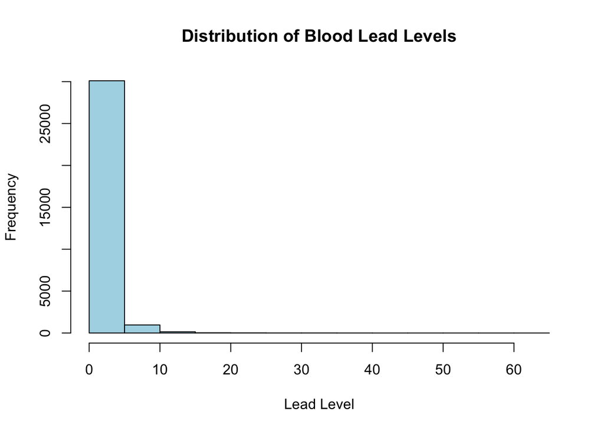

```r
# Histogram
hist(NHANESsample$LEAD,
     main = "Distribution of Blood Lead Levels",
     xlab = "Lead Level",
     col = "lightblue")
```

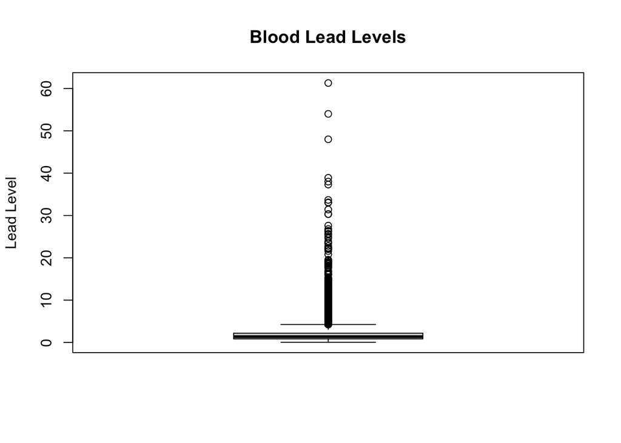

```r
# Boxplot
boxplot(NHANESsample$LEAD,
        main = "Blood Lead Levels",
        ylab = "Lead Level")
```

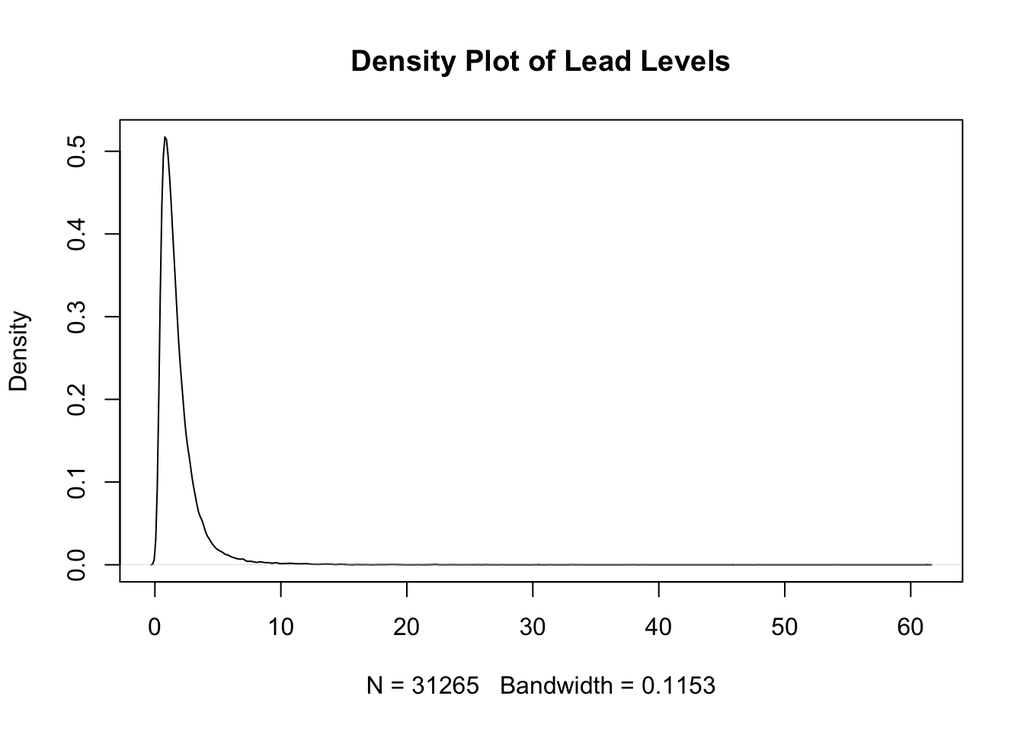

```r
# Density plot
plot(density(NHANESsample$LEAD, na.rm = TRUE),
     main = "Density Plot of Lead Levels")
```

## (C) Inference for One Parameter.

For this analysis, I will conduct inference on a single population parameter from the `HDSinRdata` package. We can do this by calculating a 95% confidence interval for the mean. The CI calculation and construction depends on the parameter type and distribution assumptions.

For a population mean: If σ is known: `CI = x̄ ± z(α/2) · (σ/√n)` If σ is unknown (more common): `CI = x̄ ± t(α/2, n-1) · (s/√n)`

For a population proportion: If the sample is large (> ~30) we can approximate a normal distribution using the Central Limit Theorem. The CLT allows us to approximate normality with large samples. The CI calculation is: `CI = p̂ ± z(α/2) · √[p̂(1-p̂)/n]` `CI = p_hat +/- z(a/2) * sqrt(p_hat(1-p_hat)/n)` Where: x̄ = sample mean, s = sample standard deviation p̂ = sample proportion n = sample size z(α/2) = critical value from standard normal distribution t(α/2, n-1) = critical value from t-distribution with n-1 degrees of freedom

Parameter of Interest: Population mean blood lead level (μ), measured in micrograms per deciliter (ug/dL). A description of our parameter from the help page is below: `Lead (ug/dL): "LBXBPB" in NHANES unless the reported level of lead was less than the lower limit of detection (llod),` + `as defined by the paper cited above, for the relevant year, in which case "LBXBPB" was replaced by llod/sqrt(2))`

Our assumptions include: (1) the sample is representative of the population (2) the variable is approximately normally distributed or the sample size is sufficiently large to invoke the Central Limit Theorem.

```r
# install packages
library(HDSinRdata)

# Load data and create a data frame
data("NHANESsample")
df <- NHANESsample

# Extract variable LEAD
x <- df$LEAD

# Calculate number, mean, standard deviation, and standard error
n <- length(x)
xbar <- mean(x, na.rm = TRUE)
s <- sd(x, na.rm = TRUE)
se <- s / sqrt(n)

# Set confidence level of 95%
conf_level <- 0.95
alpha <- 1 - conf_level

# Calculate critical value from the t-distribution
t_crit <- qt(1 - alpha/2, df = n - 1)

# Calculate confidence interval
margin_of_error <- t_crit * se
ci_lower <- xbar - margin_of_error
ci_upper <- xbar + margin_of_error

# Display results
cat("========================================\n")
cat("Confidence Interval for Mean Blood Lead Level\n")
cat("Sample size (n):", n, "\n")
cat("Sample mean (x̄):", xbar, "\n")
cat("Sample standard deviation (s):", round(s, 4), "ug/dL\n")
cat("Standard error (SE):", se, "\n")
cat("Degrees of freedom:", n - 1, "\n")
cat("t-critical value:", round(t_crit, 4), "\n")
cat("Margin of error:", round(margin_of_error, 4), "ug/dL\n")
cat(conf_level*100, "% Confidence Interval: [", round(ci_lower, 4), ",", round(ci_upper, 4), "]\n")
cat("========================================\n")
```

```
## ========================================
## Confidence Interval for Mean Blood Lead Level
## Sample size (n): 31265
## Sample mean (x̄): 1.804523
## Sample standard deviation (s): 1.8127 ug/dL
## Standard error (SE): 0.01025168
## Degrees of freedom: 31264
## t-critical value: 1.96
## Margin of error: 0.0201 ug/dL
## 95 % Confidence Interval: [ 1.7844 , 1.8246 ]
## ========================================
```

## Visualizations

We can create a Q-Q plot to check our assumptions of normality. If the data points in the Q-Q plot fall close along this straight line it suggests that the data is normally distributed.

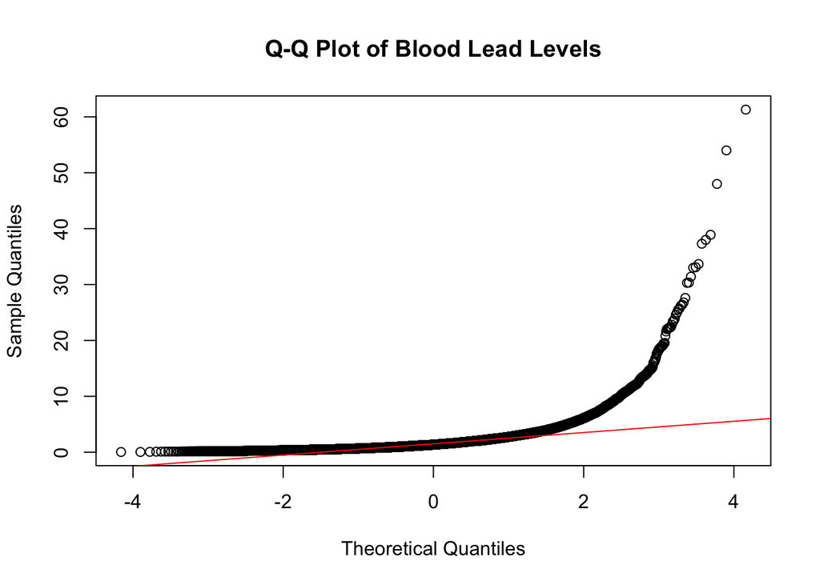

```r
# We can create a Q-Q plot to check our assumptions of normality. If the data points in the Q-Q plot fall close along this straight line it suggests that the data is normally distributed.
qqnorm(x, main = "Q-Q Plot of Blood Lead Levels")
qqline(x, col = "red")
```

## Histogram to visualize distribution

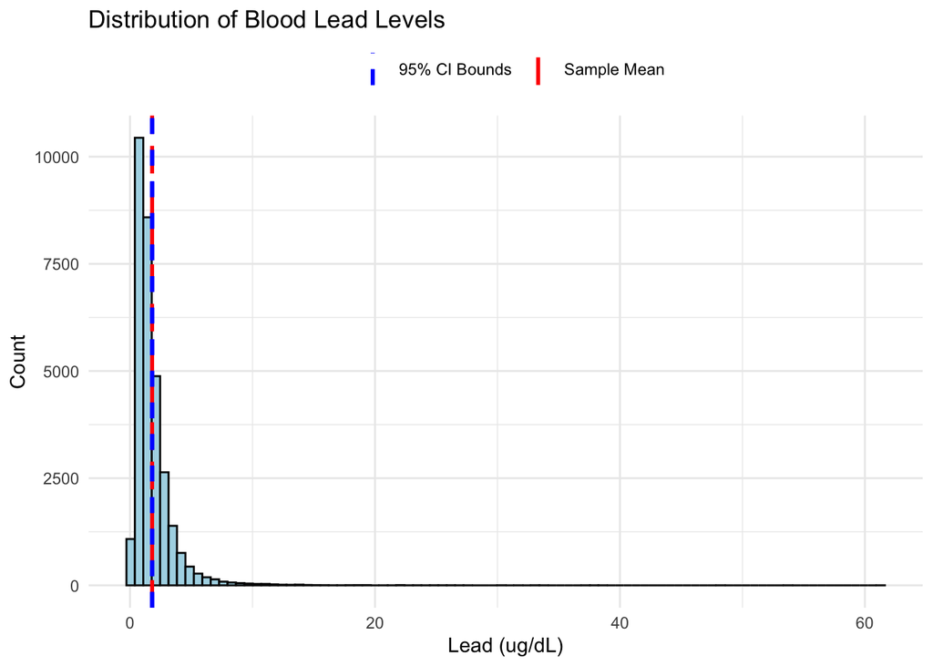

```r
# Histogram to visualize distribution
library(ggplot2)

ggplot(data.frame(x = x), aes(x = x)) +
  geom_histogram(bins = 90, fill = "lightblue", color = "black") +
  geom_vline(aes(xintercept = xbar, color = "Sample Mean"),
             linetype = "longdash", linewidth = 1) +
  geom_vline(aes(xintercept = ci_lower, color = "95% CI Bounds"),
             linetype = "dashed", linewidth = 1) +
  geom_vline(aes(xintercept = ci_upper, color = "95% CI Bounds"),
             linetype = "dashed", linewidth = 1) +
  scale_color_manual(name = "",
                     values = c("Sample Mean" = "red", "95% CI Bounds" = "blue")) +
  labs(title = "Distribution of Blood Lead Levels",
       x  = "Lead (ug/dL)",
       y = "Count") +
  theme_minimal() +
  theme(legend.position = "top")
```

Interpretation: Based on the analysis of the mean blood lead level x_bar = 1.8045 ug/dL with a standard error of 0.0103 ug/dL. We can interpret this result as follows: If we were to repeatedly sample from this population and construct a 95% confidence interval using the same methodology, approximately 95% of such intervals would contain the true population mean blood lead level. This interval provides a range of plausible values for the average blood lead level in the population from which this sample was drawn (accounting for sampling variability).

## (D) Optional: Comparison Between Two Groups Using Bootstrap.

The bootstrap is a resampling technique that estimates the sampling distribution of a statistic by repeatedly sampling with replacement from the observed data. For comparing two groups, bootstrap methods provide several advantages. - They do not require normality assumptions - They can construct confidence interval for complex statistics - They provided robust inference when the sample size is moderate - They account for the variability in both groups

```r
# Load required packages
library(HDSinRdata)

# Load the data
data(NHANESsample)

# Compare lead levels between males and females
table(NHANESsample$SEX)
```

```
##
##   Male Female
##  16468  14797
```

```r
# Create clean data set with complete cases for analysis
analysis_data <- NHANESsample[!is.na(NHANESsample$LEAD) &
                               !is.na(NHANESsample$SEX), ]

# Create separate lead groups for each gender
group1 <- analysis_data$LEAD[analysis_data$SEX == "Male"]
group2 <- analysis_data$LEAD[analysis_data$SEX == "Female"]

# Calculate the difference in means
observed_diff <- mean(group1) - mean(group2)

cat("Group 1 (Male) sample size:", length(group1), "\n")
cat("Group 2 (Female) sample size:", length(group2), "\n")
cat("Observed difference in means:", round(observed_diff, 4), "ug/dL\n\n")

# Bootstrap procedure
set.seed(806)
B <- 10000  # Number of bootstrap samples
boot_diffs <- numeric(B) # Create a numeric vector with length 10000 (empty at this time)


for(i in 1:B) {
  # Resample from each group with replacement
  boot_group1 <- sample(group1, size = length(group1), replace = TRUE)
  boot_group2 <- sample(group2, size = length(group2), replace = TRUE)

  # Calculate the difference in means
  boot_diffs[i] <- mean(boot_group1) - mean(boot_group2)
}


# Calculate a 95% confidence interval
conf_level <- 0.95
alpha <- 1 - conf_level
boot_ci_lower <- quantile(boot_diffs, alpha/2, na.rm = TRUE)
boot_ci_upper <- quantile(boot_diffs, 1 - alpha/2, na.rm = TRUE)

# Display results
cat("========================================\n")
cat("Bootstrap Comparison of Two Groups\n")
cat("========================================\n")
cat("Number of bootstrap samples:", B, "\n")
cat("Observed difference (Group 1 - Group 2):", round(observed_diff, 4), "ug/dL\n")
cat("Bootstrap mean:", round(mean(boot_diffs), 4), "ug/dL\n")
cat("Bootstrap SE:", round(sd(boot_diffs), 4), "ug/dL\n")
cat(conf_level*100, "% Bootstrap CI: [",
    round(boot_ci_lower, 4), ",", round(boot_ci_upper, 4), "] ug/dL\n")
cat("========================================\n")
```

```
## Group 1 (Male) sample size: 16468
## Group 2 (Female) sample size: 14797
## Observed difference in means: 0.7763 ug/dL
##
## ========================================
## Bootstrap Comparison of Two Groups
## ========================================
## Number of bootstrap samples: 10000
## Observed difference (Group 1 - Group 2): 0.7763 ug/dL
## Bootstrap mean: 0.7763 ug/dL
## Bootstrap SE: 0.0194 ug/dL
## 95 % Bootstrap CI: [ 0.7386 , 0.8148 ] ug/dL
## ========================================
```

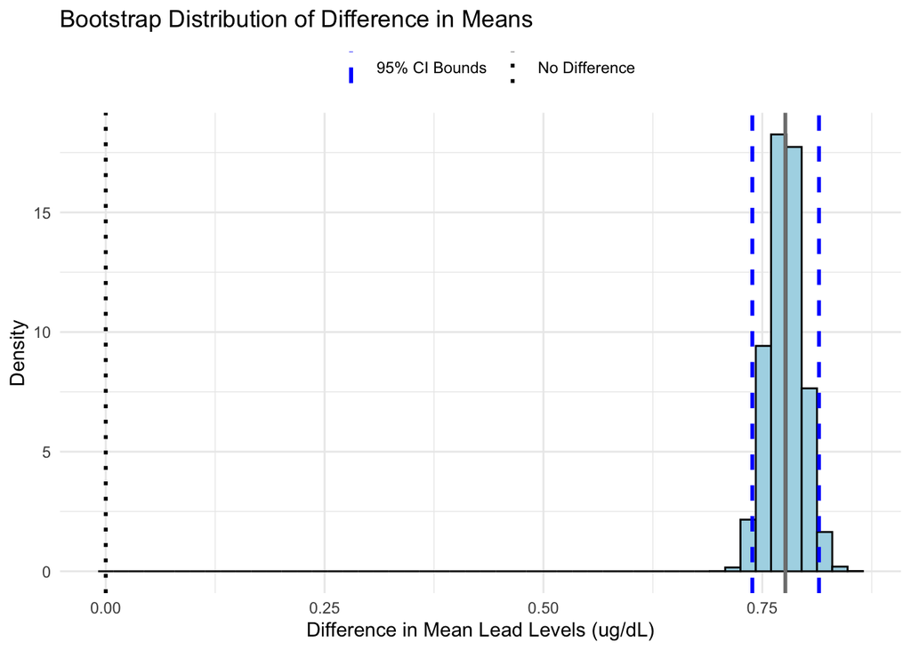

```r
# Visualize bootstrap distribution
library(ggplot2)

ggplot(data.frame(diff = boot_diffs), aes(x = diff)) +
  geom_histogram(bins = 50, fill = "lightblue", color = "black", aes(y = after_stat(density))) +
  geom_vline(aes(xintercept = observed_diff, color = "Observerd Difference"),
             linetype = "solid", linewidth = 1) +
  geom_vline(aes(xintercept = boot_ci_lower, color = "95% CI Bounds"),
             linetype = "dashed", linewidth = 1) +
  geom_vline(aes(xintercept = boot_ci_upper, color = "95% CI Bounds"),
             linetype = "dashed", linewidth = 1) +
  geom_vline(aes(xintercept = 0, color = "No Difference"),
             linetype = "dotted", linewidth = 1) +
  scale_color_manual(name = "",
                     values = c("Observed Difference" = "red",
                                "95% CI Bounds" = "blue",
                                "No Difference" = "black")) +
  labs(title = "Bootstrap Distribution of Difference in Means",
       x = "Difference in Mean Lead Levels (ug/dL)",
       y = "Density") +
  theme_minimal() +
  theme(legend.position = "top")
```

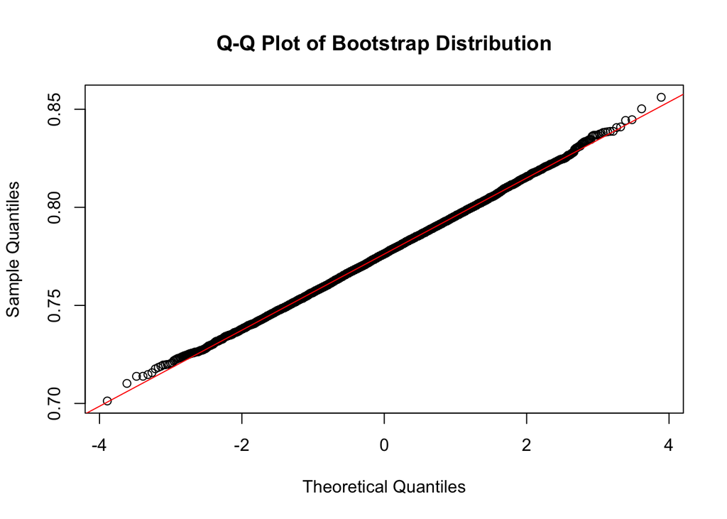

```r
# Create a Q-Q plot to assess bootstrap distribution
qqnorm(boot_diffs, main = "Q-Q Plot of Bootstrap Distribution")
qqline(boot_diffs, col = "red")
```

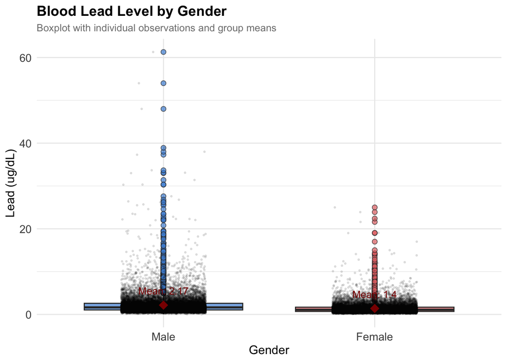

```r
# Create a side-by-side boxplot of original data using ggplot2
library(ggplot2)

# Calculate group means for annotation
group_means <- aggregate(LEAD ~ SEX, data = analysis_data, FUN = mean)

ggplot(analysis_data, aes(x = SEX, y = LEAD, fill = SEX)) +
  geom_boxplot(alpha = 0.7, outlier.shape = 21, outlier.size = 2) +
  geom_jitter(width = 0.2, alpha = 0.1, size = 0.5) +
  stat_summary(fun = mean, geom = "point", shape = 18, size = 4, color = "darkred") +
  stat_summary(fun = mean, geom = "text", aes(label = paste("Mean:", round(after_stat(y), 2))),
               vjust = -1.5, size = 3.5, color = "darkred") +
  scale_fill_manual(values = c("Male" = "#4A90D9", "Female" = "#E57373")) +
  labs(title = "Blood Lead Level by Gender",
       subtitle = "Boxplot with individual observations and group means",
       x = "Gender",
       y = "Lead (ug/dL)") +
  theme_minimal() +
  theme(legend.position = "none",
        plot.title = element_text(face = "bold", size = 14),
        plot.subtitle = element_text(color = "gray50", size = 10),
        axis.text = element_text(size = 11),
        axis.title = element_text(size = 12))
```

Interpretation: The bootstrap analysis reveals a statistically significant difference in mean blood lead levels between males and females. The observed difference of 0.7763 ug/dL indicates that males have higher average blood lead levels than females. The 95% bootstrap confidence interval [0.7386, 0.8148] dose not contain zero, providing strong evidence that this difference is not due to random sampling variability alone.

The bootstrap distribution appears approximately normal (as shown in the Q-Q plot), which supports the validity of our confidence interval. Since zero falls outside the confidence interval, we can conclude at the 95% confidence level that their is a meaningful difference in blood lead levels between genders in this population.

## Conclusion

This anallysis examined blood lead levels from the NHANES dataset using both classical and bootstrap statistical methods. The key findings are:

1. **Descriptive Statistic**: The distribution of blood lead levels is right-skewed, with a mean of 1.8045 ug/dL and considerable variabilriy in the population.
2. **Confidence Interval for the Mean**: Using t-distribution methods, we constructed a 95% confidence interval for the popluation mean blood lead level, providing a range of plausible valies for this parameter.
3. **Gender Comparison**: Bootstrap resampling revealed a statistically significant difference in blood lead levels between males and females, with males exibiting higher average levels. The 95% bootstrpa confidence interval for the difference did not include zero, supporting the conclusion that this difference is unlikely due to chance alone.

**Limitations**: This analysis is observational an dcannot establish causation. Additionally, while the sample size is large, the data may not be perfectly representative of all U.S. adults. Future analysis could explore potential confounding variables such as age, occoupation, or geographic region.

*Thank you for taking the time to review this analysis. The methods and interpertations presented here reflect the statistical concepts covered in Stats 521, and I hope this report demonstrates a clear understanding of confidence intervals, and bootstrap methods.*